# Caso Práctico 6 a)

Marcos Barragán

28/11/2020

# Objetivo:

Este caso práctico presenta dos objetivos principales:

- Por un lado, generar un modelo GARCH para corregir la heteocedasticidad de la varianza residual de los rendimientos de BMW como serie temporal.
- Por otro lado, generaremos modelos VAR con el fin de comparar los efectos dinámicos de BMW y Volkswagen.

## 1) Datos históricos de BMW y Volkswagen:

A través de la librería *quantmod* cargamos los datos de `BMW` (BMW.DE) y Volkswagen (`VOW.DE`).

```r
#BMW se llama BMW.DE en Yahoo Finance. Tomamos desde el 1 de Enero de 2014 hasta hoy (finales de Noviembre 2020).

getSymbols('BMW.DE', from = '2014-01-01', to = Sys.Date())
```

[output not shown]

```
## [1] "BMW.DE"
```

```r
BMW <- BMW.DE[,6]

#VolksWagen se llama VOW.DE en Yahoo Finance.

getSymbols('VOW.DE', from = '2014-01-01', to = Sys.Date())
```

```
## [1] "VOW.DE"
```

```r
VW <- VOW.DE[,6]
```

Si representamos el precio de las acciones de `BMW` y `Volkswagen` en función del tiempo.

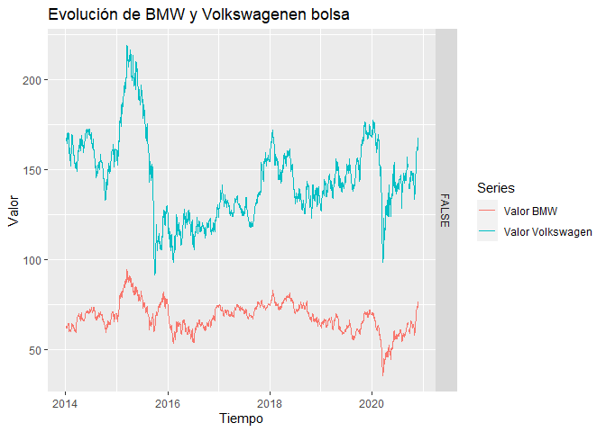

```r
BMW_VW <- cbind(BMW, VW)

names(BMW_VW) <- c('Valor BMW', 'Valor Volkswagen')

autoplot(BMW_VW, facets = FALSE) + #facets FALSE para que salgan las dos en el mismo gráfico.
  ggtitle("Evolución de BMW y Volkswagenen bolsa") +
  xlab("Tiempo") +
  ylab("Valor")
```

### 1.1) Rentabilidades BMW:

Las rentabilidades de BMW las calcularemos a partir de la función *dailyReturn*, presente en el paquete quantmod, que nos devuelve los rendimientos diarios de los activos sin necesidad de tener que definir funciones que lo hagan. Esto es:

```r
BMW_rent <- dailyReturn(BMW, type = 'log', leading=FALSE)
BMW_rent <- na.exclude(BMW_rent)

head(BMW_rent)
```

```
##            daily.returns
## 2014-01-03   0.005253307
## 2014-01-06  -0.011858764
## 2014-01-07   0.006725374
## 2014-01-08   0.010714238
## 2014-01-09  -0.007010826
## 2014-01-10  -0.008502746
```

La volatilidad la calcularemos, en este caso, como el cuadrado de las rentabilidades.

```r
BMW_vol <- BMW_rent^2
```

Podemos estudiar el comportamiento del precio, la rentabilidad y la volatilidad de los activos en un mismo gráfico:

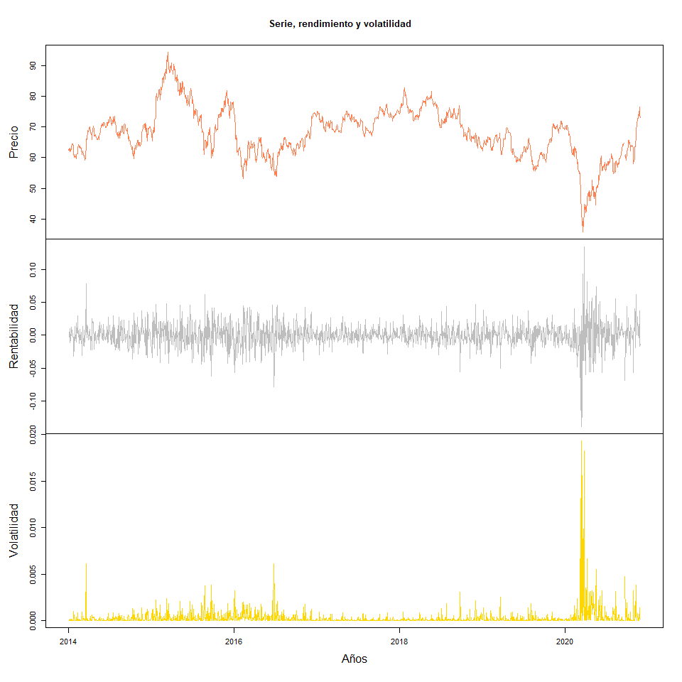

```r
#plot.zoo(cbind(BMW, BMW_rent))

plot.zoo(cbind((BMW), BMW_rent, BMW_vol), main = 'Serie, rendimiento y volatilidad', xlab = 'Años', ylab = c('Precio', 'Rentabilidad', 'Volatilidad'), col = c('coral', 'grey', 'gold'))
```

Si contrastamos la media de los rendimientos del activo BMW, a través de una t de Student, para saber si presenta media nula o no:

```r
t.test(BMW_rent) # no rechazamos media = 0
```

```
##
##  One Sample t-test
##
## data:  BMW_rent
## t = 0.21196, df = 1748, p-value = 0.8322
## alternative hypothesis: true mean is not equal to 0
## 95 percent confidence interval:
##  -0.0007406791  0.0009201661
## sample estimates:
##   mean of x
## 8.97435e-05
```

El hecho de obtener un $p_{value} = 0.8322$ nos dice que no podemos rechazar la hipótesis nula de que la media de los rendimientos sea nula.

```r
Box.test(BMW_vol, lag=10,  type="Lj")
```

```
##
##  Box-Ljung test
##
## data:  BMW_vol
## X-squared = 760.79, df = 10, p-value < 2.2e-16
```

```r
Box.test(BMW_vol, lag=20,  type="Lj")
```

```
##
##  Box-Ljung test
##
## data:  BMW_vol
## X-squared = 993.66, df = 20, p-value < 2.2e-16
```

```r
Box.test(BMW_vol, lag=40,  type="Lj")
```

```
##
##  Box-Ljung test
##
## data:  BMW_vol
## X-squared = 1230.8, df = 40, p-value < 2.2e-16
```

```r
T.Lag <- function(r,m){
  y = (r - mean(r))^2
  t = length(r)
  a = y [(m +1) : t]
  x = matrix(0, (t - m), m)
  for (i in 1:m){
    x[,i] = y [(m+1-i):(t-i)]
  }
  md = lm(a~x)
  summary(md)
}
```

```r
T.Lag(BMW_rent, m = 20)
```

```
##
## Call:
## lm(formula = a ~ x)
##
## Residuals:
##        Min         1Q     Median         3Q        Max
## -0.0047684 -0.0002218 -0.0001073  0.0000544  0.0181166
##
## Coefficients:
##               Estimate Std. Error t value Pr(>|t|)
## (Intercept)  9.000e-05  2.557e-05   3.519 0.000444 ***
## x1          -3.635e-02  2.416e-02  -1.505 0.132576
## x2           2.366e-01  2.417e-02   9.787  < 2e-16 ***
## x3           9.265e-02  2.479e-02   3.738 0.000192 ***
## x4          -1.179e-02  2.490e-02  -0.474 0.635720
## x5           8.426e-02  2.489e-02   3.386 0.000726 ***
## x6           2.478e-01  2.497e-02   9.921  < 2e-16 ***
## x7          -2.280e-02  2.559e-02  -0.891 0.373151
## x8           1.235e-01  2.552e-02   4.839 1.42e-06 ***
## x9           7.497e-02  2.568e-02   2.919 0.003553 **
## x10         -4.162e-02  2.568e-02  -1.621 0.105223
## x11          7.900e-02  2.568e-02   3.076 0.002130 **
## x12         -4.406e-02  2.569e-02  -1.715 0.086478 .
## x13         -8.408e-02  2.554e-02  -3.291 0.001017 **
## x14         -8.908e-02  2.562e-02  -3.476 0.000521 ***
## x15          1.820e-02  2.511e-02   0.725 0.468544
## x16         -1.169e-02  2.503e-02  -0.467 0.640494
## x17         -7.626e-03  2.503e-02  -0.305 0.760654
## x18          6.754e-02  2.492e-02   2.710 0.006793 **
## x19         -1.440e-02  2.431e-02  -0.592 0.553891
## x20          5.537e-02  2.430e-02   2.278 0.022826 *
## ---
## Signif. codes:  0 '***' 0.001 '**' 0.01 '*' 0.05 '.' 0.1 ' ' 1
##
## Residual standard error: 0.0008736 on 1708 degrees of freedom
## Multiple R-squared:  0.2415, Adjusted R-squared:  0.2326
## F-statistic: 27.19 on 20 and 1708 DF,  p-value: < 2.2e-16
```

De nuevo obtenemos un $p_{value} = 2.2·10^{-16}$, por lo que rechazamos la hipótesis de que no es necesario llevar a cabo un modelo GARCH para estos datos. Esto se traduce en que será necesario estimar un modelo generalizado de heteroscedasticidad condicionadal (GARCH).

## 2) Implementamos el modelo GARCH:

Al implementar el modelo GARCH(1,1) y pedirle que nos devuelve las gráficas correspondientes, debemos especificarle claramente cuál es el que queremos.

```r
garch11 <- garchFit(~1 + garch(1,1), data = BMW_rent, trace = FALSE)
summary(garch11)
```

```
##
## Title:
##  GARCH Modelling
##
## Call:
##  garchFit(formula = ~1 + garch(1, 1), data = BMW_rent, trace = FALSE)
##
## Mean and Variance Equation:
##  data ~ 1 + garch(1, 1)
## <environment: 0x0000000024156e20>
##  [data = BMW_rent]
##
## Conditional Distribution:
##  norm
##
## Coefficient(s):
##         mu       omega      alpha1       beta1
## 3.0532e-04  2.5007e-06  4.9894e-02  9.4273e-01
##
## Std. Errors:
##  based on Hessian
##
## Error Analysis:
##         Estimate  Std. Error  t value Pr(>|t|)
## mu     3.053e-04   3.360e-04    0.909   0.3635
## omega  2.501e-06   9.781e-07    2.557   0.0106 *
## alpha1 4.989e-02   8.002e-03    6.235  4.5e-10 ***
## beta1  9.427e-01   9.548e-03   98.734  < 2e-16 ***
## ---
## Signif. codes:  0 '***' 0.001 '**' 0.01 '*' 0.05 '.' 0.1 ' ' 1
##
## Log Likelihood:
##  4799.462    normalized:  2.744118
##
## Description:
##  Mon Nov 30 22:47:58 2020 by user: Barra
##
##
## Standardised Residuals Tests:
##                                 Statistic p-Value
##  Jarque-Bera Test   R    Chi^2  749.4246  0
##  Shapiro-Wilk Test  R    W      0.9722568 0
##  Ljung-Box Test     R    Q(10)  21.9004   0.01562014
##  Ljung-Box Test     R    Q(15)  26.40683  0.03395787
##  Ljung-Box Test     R    Q(20)  32.28662  0.04033832
##  Ljung-Box Test     R^2  Q(10)  21.35063  0.01877703
##  Ljung-Box Test     R^2  Q(15)  22.86262  0.08710055
##  Ljung-Box Test     R^2  Q(20)  26.26798  0.1571427
##  LM Arch Test       R    TR^2   21.86675  0.03904063
##
## Information Criterion Statistics:
##       AIC       BIC       SIC      HQIC
## -5.483661 -5.471159 -5.483672 -5.479039
```

```r
resi <- residuals(garch11, standardize = TRUE)

resi <- xts(resi, order.by = index(BMW_rent))

tsdisplay(resi^2)
```

[figure not shown]

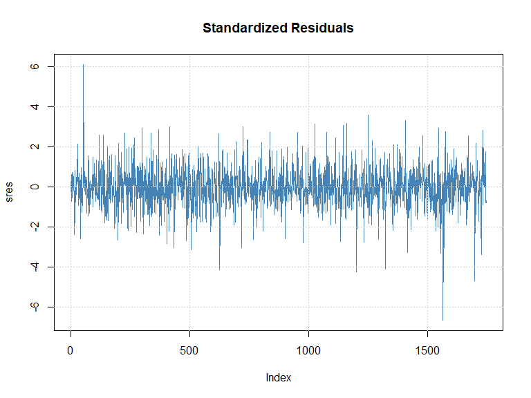

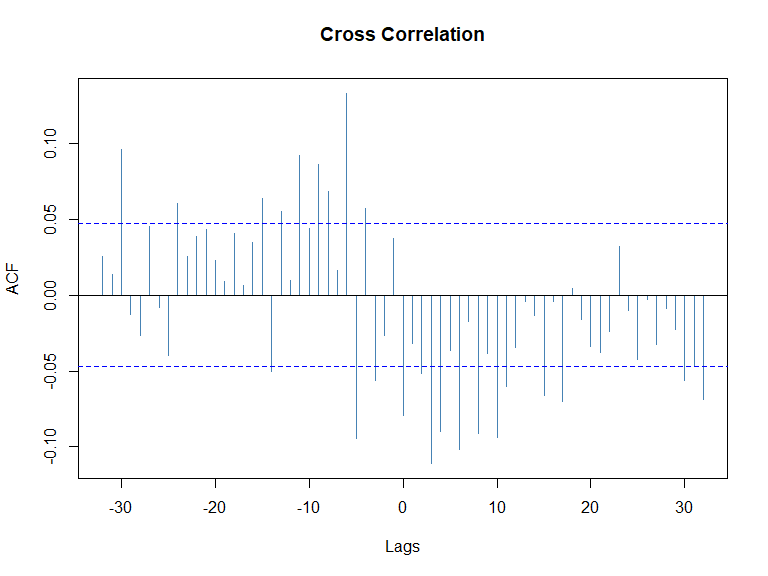

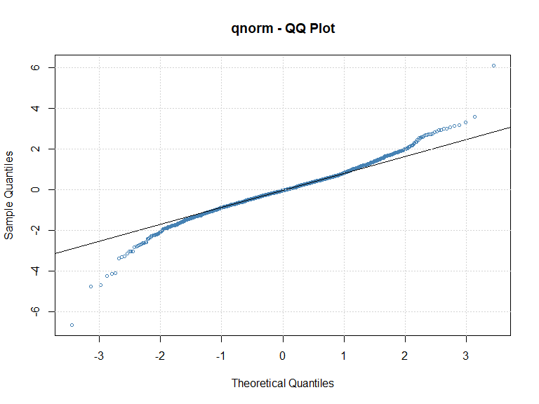

```r
plot(garch11, which = c(9, 12, 13))
```

```r
Box.test(resi , lag=10,  type="Lj")
```

```
##
##  Box-Ljung test
##
## data:  resi
## X-squared = 21.9, df = 10, p-value = 0.01562
```

Si representamos la volatilidad obtenida para este modelo GARCH(1, 1)

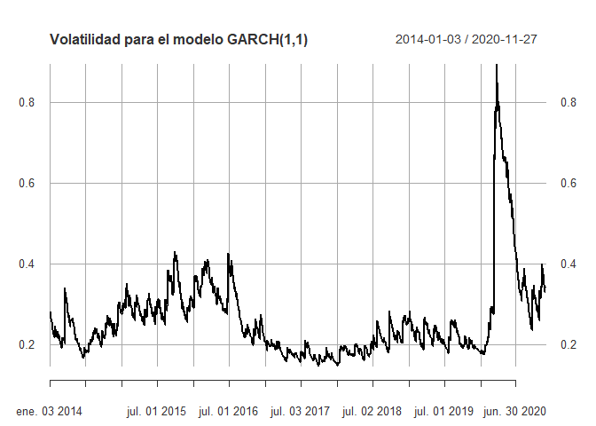

```r
vol_garch11 <- volatility(garch11)

vol_garch11 <- xts(vol_garch11, order.by = index(BMW_rent)) #  Volatilidad en forma de XTS

plot(sqrt(252)*vol_garch11, main = 'Volatilidad para el modelo GARCH(1,1)')
```

```r
predict(garch11)
```

```
##    meanForecast  meanError standardDeviation
## 1  0.0003053166 0.02109821        0.02109821
## 2  0.0003053166 0.02107965        0.02107965
## 3  0.0003053166 0.02106120        0.02106120
## 4  0.0003053166 0.02104288        0.02104288
## 5  0.0003053166 0.02102467        0.02102467
## 6  0.0003053166 0.02100658        0.02100658
## 7  0.0003053166 0.02098861        0.02098861
## 8  0.0003053166 0.02097076        0.02097076
## 9  0.0003053166 0.02095302        0.02095302
## 10 0.0003053166 0.02093540        0.02093540
```

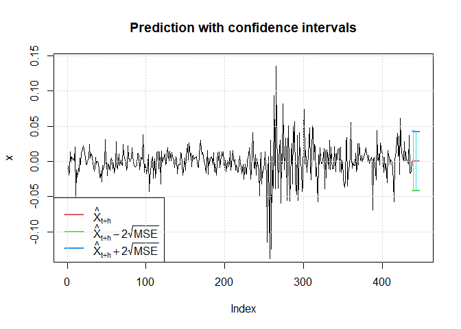

```
##    meanForecast  meanError standardDeviation lowerInterval upperInterval
## 1  0.0003053166 0.02109821        0.02109821   -0.04189111    0.04250175
## 2  0.0003053166 0.02107965        0.02107965   -0.04185398    0.04246461
## 3  0.0003053166 0.02106120        0.02106120   -0.04181709    0.04242772
## 4  0.0003053166 0.02104288        0.02104288   -0.04178044    0.04239107
## 5  0.0003053166 0.02102467        0.02102467   -0.04174402    0.04235466
## 6  0.0003053166 0.02100658        0.02100658   -0.04170785    0.04231848
## 7  0.0003053166 0.02098861        0.02098861   -0.04167191    0.04228254
## 8  0.0003053166 0.02097076        0.02097076   -0.04163620    0.04224684
## 9  0.0003053166 0.02095302        0.02095302   -0.04160073    0.04221137
## 10 0.0003053166 0.02093540        0.02093540   -0.04156549    0.04217613
```

```r
predict(garch11, n.ahead = 10, plot = TRUE, crit_val = 2)
```

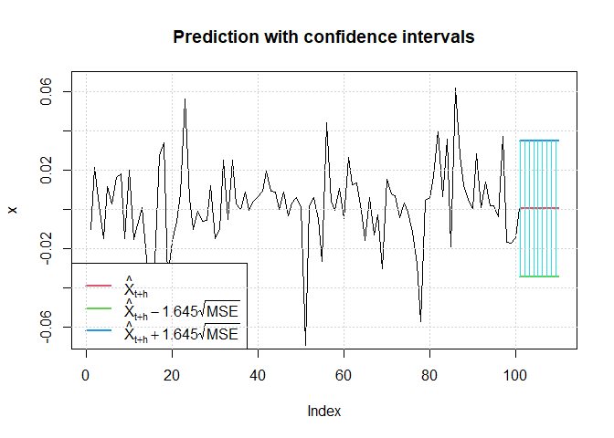

```
##    meanForecast  meanError standardDeviation lowerInterval upperInterval
## 1  0.0003053166 0.02109821        0.02109821   -0.03439816    0.03500879
## 2  0.0003053166 0.02107965        0.02107965   -0.03436762    0.03497825
## 3  0.0003053166 0.02106120        0.02106120   -0.03433728    0.03494791
## 4  0.0003053166 0.02104288        0.02104288   -0.03430713    0.03491777
## 5  0.0003053166 0.02102467        0.02102467   -0.03427719    0.03488782
## 6  0.0003053166 0.02100658        0.02100658   -0.03424744    0.03485807
## 7  0.0003053166 0.02098861        0.02098861   -0.03421788    0.03482851
## 8  0.0003053166 0.02097076        0.02097076   -0.03418851    0.03479915
## 9  0.0003053166 0.02095302        0.02095302   -0.03415934    0.03476998
## 10 0.0003053166 0.02093540        0.02093540   -0.03413036    0.03474099
```

```r
predict(garch11, n.ahead = 10, plot = TRUE, conf = .9, nx = 100)
```

```r
garch22 <- garchFit(~1 + garch(1,2), data = BMW_rent, trace = FALSE)
summary(garch22)
```

```
##
## Title:
##  GARCH Modelling
##
## Call:
##  garchFit(formula = ~1 + garch(1, 2), data = BMW_rent, trace = FALSE)
##
## Mean and Variance Equation:
##  data ~ 1 + garch(1, 2)
## <environment: 0x00000000233ec7a0>
##  [data = BMW_rent]
##
## Conditional Distribution:
##  norm
##
## Coefficient(s):
##         mu       omega      alpha1       beta1       beta2
## 3.4216e-04  3.5784e-06  7.7461e-02  3.3048e-01  5.8200e-01
##
## Std. Errors:
##  based on Hessian
##
## Error Analysis:
##         Estimate  Std. Error  t value Pr(>|t|)
## mu     3.422e-04   3.361e-04    1.018 0.308661
## omega  3.578e-06   1.454e-06    2.461 0.013837 *
## alpha1 7.746e-02   1.372e-02    5.648 1.63e-08 ***
## beta1  3.305e-01   1.796e-01    1.840 0.065714 .
## beta2  5.820e-01   1.730e-01    3.364 0.000768 ***
## ---
## Signif. codes:  0 '***' 0.001 '**' 0.01 '*' 0.05 '.' 0.1 ' ' 1
##
## Log Likelihood:
##  4799.502    normalized:  2.744141
##
## Description:
##  Mon Nov 30 22:47:59 2020 by user: Barra
##
##
## Standardised Residuals Tests:
##                                 Statistic p-Value
##  Jarque-Bera Test   R    Chi^2  712.4504  0
##  Shapiro-Wilk Test  R    W      0.9729166 0
##  Ljung-Box Test     R    Q(10)  21.27659  0.01924532
##  Ljung-Box Test     R    Q(15)  26.03234  0.03768416
##  Ljung-Box Test     R    Q(20)  31.90182  0.04435575
##  Ljung-Box Test     R^2  Q(10)  18.48265  0.04734768
##  Ljung-Box Test     R^2  Q(15)  19.90858  0.1754679
##  Ljung-Box Test     R^2  Q(20)  23.36449  0.2712538
##  LM Arch Test       R    TR^2   18.62491  0.09799154
##
## Information Criterion Statistics:
##       AIC       BIC       SIC      HQIC
## -5.482564 -5.466936 -5.482580 -5.476787
```

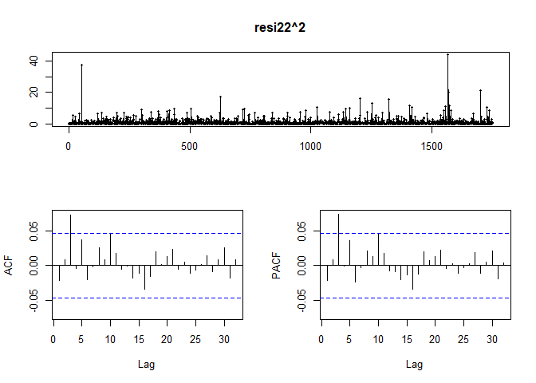

```r
resi22 <- residuals(garch22, standardize = TRUE)

resi22 <- xts(resi22, order.by = index(BMW_rent))

tsdisplay(resi22^2)
```

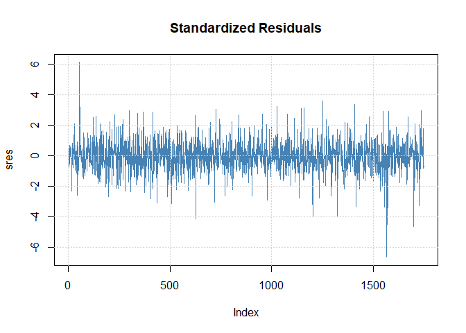

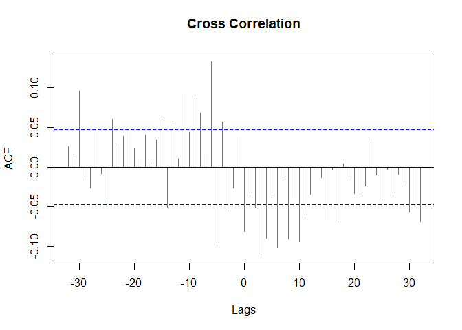

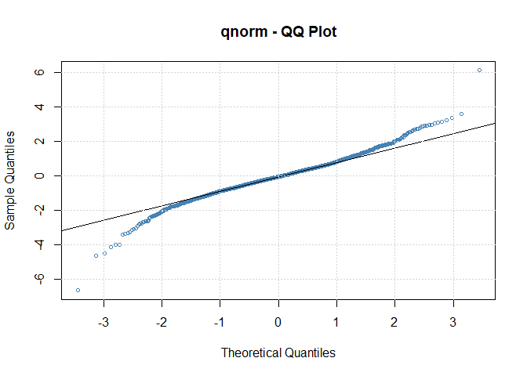

```r
plot(garch22, which = c(9, 12, 13))
```

## 3) Modelos VAR:

A continuación generaremos un modelo VAR sobre el DataFrame con las series de rendimientos de `BMW` y `Volkswagen`.

Los rendimientos de `BMW` los calculamos al inicio, antes de implementar los modelos GARCH, pero no teníamos los de Volkswagen. Los calculo a continuación y genero un DataFrame que contenga los rendimientos de ambos activos.

```r
VOL_rent <- dailyReturn(VW)
rent <- cbind(BMW_rent, VOL_rent)

names(rent) <- c('Rendimientos BMW', 'Rendimientos Volkswagen')

rent <- na.omit(rent)

head(rent)
```

```
##            Rendimientos BMW Rendimientos Volkswagen
## 2014-01-03      0.005253307            -0.004903015
## 2014-01-06     -0.011858764            -0.003112266
## 2014-01-07      0.006725374             0.007023933
## 2014-01-08      0.010714238            -0.001808413
## 2014-01-09     -0.007010826            -0.001035123
## 2014-01-10     -0.008502746             0.009844586
```

Si implementamos el modelo VAR sobre los rendimientos de los activos considerados:

```r
VAR_model <- VAR(rent)

summary(VAR_model)
```

```
##
## VAR Estimation Results:
## =========================
## Endogenous variables: Rendimientos.BMW, Rendimientos.Volkswagen
## Deterministic variables: const
## Sample size: 1748
## Log Likelihood: 9682.731
## Roots of the characteristic polynomial:
## 0.05349 0.0449
## Call:
## VAR(y = rent)
##
##
## Estimation results for equation Rendimientos.BMW:
## =================================================
## Rendimientos.BMW = Rendimientos.BMW.l1 + Rendimientos.Volkswagen.l1 + const
##
##                              Estimate Std. Error t value Pr(>|t|)
## Rendimientos.BMW.l1        -6.782e-02  3.667e-02  -1.850 0.064534 .
## Rendimientos.Volkswagen.l1  1.105e-01  3.237e-02   3.413 0.000657 ***
## const                       7.289e-05  4.223e-04   0.173 0.862990
## ---
## Signif. codes:  0 '***' 0.001 '**' 0.01 '*' 0.05 '.' 0.1 ' ' 1
##
##
## Residual standard error: 0.01766 on 1745 degrees of freedom
## Multiple R-Squared: 0.007367,    Adjusted R-squared: 0.006229
## F-statistic: 6.475 on 2 and 1745 DF,  p-value: 0.001579
##
##
## Estimation results for equation Rendimientos.Volkswagen:
## ========================================================
## Rendimientos.Volkswagen = Rendimientos.BMW.l1 + Rendimientos.Volkswagen.l1 + const
##
##                              Estimate Std. Error t value Pr(>|t|)
## Rendimientos.BMW.l1        -0.0251778  0.0416106  -0.605   0.5452
## Rendimientos.Volkswagen.l1  0.0764186  0.0367291   2.081   0.0376 *
## const                       0.0001720  0.0004793   0.359   0.7197
## ---
## Signif. codes:  0 '***' 0.001 '**' 0.01 '*' 0.05 '.' 0.1 ' ' 1
##
##
## Residual standard error: 0.02004 on 1745 degrees of freedom
## Multiple R-Squared: 0.003754,    Adjusted R-squared: 0.002612
## F-statistic: 3.288 on 2 and 1745 DF,  p-value: 0.03758
##
##
##
## Covariance matrix of residuals:
##                         Rendimientos.BMW Rendimientos.Volkswagen
## Rendimientos.BMW               0.0003117               0.0002684
## Rendimientos.Volkswagen        0.0002684               0.0004015
##
## Correlation matrix of residuals:
##                         Rendimientos.BMW Rendimientos.Volkswagen
## Rendimientos.BMW                  1.0000                  0.7587
## Rendimientos.Volkswagen           0.7587                  1.0000
```

```r
causality(VAR_model)
```

```
## $Granger
##
##  Granger causality H0: Rendimientos.BMW do not Granger-cause
##  Rendimientos.Volkswagen
##
## data:  VAR object VAR_model
## F-Test = 0.36612, df1 = 1, df2 = 3490, p-value = 0.5452
##
##
## $Instant
##
##  H0: No instantaneous causality between: Rendimientos.BMW and
##  Rendimientos.Volkswagen
##
## data:  VAR object VAR_model
## Chi-squared = 638.64, df = 1, p-value < 2.2e-16
```

```r
VAR.irf <- irf(VAR_model)

VAR.irf
```

```
##
## Impulse response coefficients
## $Rendimientos.BMW
##       Rendimientos.BMW Rendimientos.Volkswagen
##  [1,]     1.765640e-02            1.520290e-02
##  [2,]     4.818502e-04            7.172350e-04
##  [3,]     4.654672e-05            4.267816e-05
##  [4,]     1.557419e-06            2.089461e-06
##  [5,]     1.251777e-07            1.204613e-07
##  [6,]     4.816577e-09            6.053787e-09
##  [7,]     3.420407e-10            3.413511e-10
##  [8,]     1.450837e-11            1.747374e-11
##  [9,]     9.461903e-13            9.700299e-13
## [10,]     4.297869e-14            5.030534e-14
## [11,]     2.641908e-15            2.762154e-15
```

[output cut: 74 more lines]

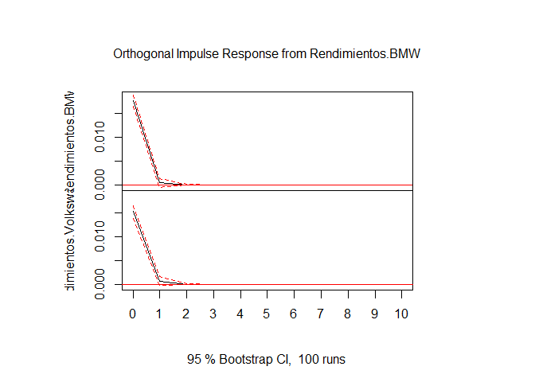

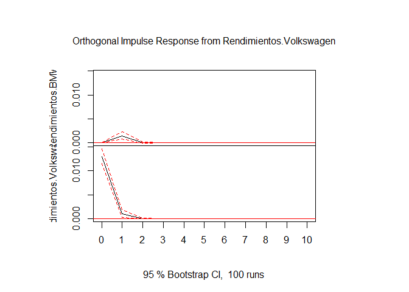

```r
plot(VAR.irf)
```

```r
predict(VAR_model, plot = TRUE, n.ahead = 8, ci = 0.95)
```

```
## $Rendimientos.BMW
##              fcst       lower      upper         CI
## [1,] 7.827593e-05 -0.03452762 0.03468418 0.03460590
## [2,] 5.306615e-05 -0.03468085 0.03478698 0.03473392
## [3,] 8.696923e-05 -0.03464707 0.03482101 0.03473404
## [4,] 8.720018e-05 -0.03464684 0.03482124 0.03473404
## [5,] 8.728358e-05 -0.03464676 0.03482133 0.03473404
## [6,] 8.728486e-05 -0.03464676 0.03482133 0.03473404
## [7,] 8.728507e-05 -0.03464676 0.03482133 0.03473404
## [8,] 8.728507e-05 -0.03464676 0.03482133 0.03473404
##
## $Rendimientos.Volkswagen
##               fcst       lower      upper         CI
## [1,] -0.0001314197 -0.03940315 0.03914031 0.03927173
## [2,]  0.0001600268 -0.03918545 0.03950551 0.03934548
## [3,]  0.0001829334 -0.03916271 0.03952858 0.03934565
## [4,]  0.0001838303 -0.03916182 0.03952948 0.03934565
## [5,]  0.0001838931 -0.03916176 0.03952954 0.03934565
## [6,]  0.0001838958 -0.03916175 0.03952954 0.03934565
## [7,]  0.0001838959 -0.03916175 0.03952954 0.03934565
## [8,]  0.0001838959 -0.03916175 0.03952954 0.03934565
```